# Interaction Effects of Supplements and Dosage on Tooth Growth in Guniea Pigs

# Abstract

In 1942, during wartime food scarcity, the Canadian government faced challenges supplying its armed forces with natural sources of Vitamin C and sought to identify the necessary dietary levels for optimal health. Initial chemical assays yielded conflicting results, prompting the government to partner with McGill University to conduct a biological assay using guinea pigs, a species, like humans, incapable of synthesizing Vitamin C naturally. Because Vitamin C deficiency directly impairs dental health and odontoblast development, the study aimed to evaluate how varying supplements and dosage levels affect tooth growth. Using this historical dataset $(n = 60)$, I perform a two-way analysis of variance (ANOVA) and polynomial regression analysis to evaluate the main and interaction effects of supplement delivery method (**Orange Juice** vs. **Ascorbic Acid** (Vitamin C) and dosage level (**0.5mg**, **1.0mg**, and **2.0mg**). The results confirm a statistically significant interaction between supplement type and dosage level. Both delivery methods significantly enhance tooth growth; however, Orange Juice yields a significantly greater effect at lower dosage levels (0.5mg and 1.0mg), whereas performance between the two supplements converges at the highest dosage level (2.0mg).

# Data Preparation & Setup

### Libraries

```r
#Data Wrangling & Visualization
library(MedDataSets)
library(tidyverse) # includes dplyr, ggplot2, readr, tidyr, purrr, stringr

#Modeling & Tidying Model Output
library(broom) # for augment(), tidy(), and glance()

#ANOVA Diagnostics & Post-Hoc Analysis
library(car) # for Type II/III ANOVA tables & Levene's test
library(emmeans) # for estimated marginal means & post-hoc pairwise contrasts

#Plot Composition
library(patchwork) # for combining ggplot2 figures (+ operator)
library(kableExtra)
```

# Preliminary Exploratory Analysis

Apply the within() method convert the predictor variables, supplement and dosage to factor variables. Check the balance of the data.

```r
toothgrowth <- within(ToothGrowth_df, {fsupp = as.factor(supp);
               fdose = as.factor(dose)})

#Check balance
toothgrowth |>
  group_by(fsupp, fdose) |>
  count()
```

| fsupp | fdose | n |
| --- | --- | --- |
| OJ | 0.5 | 10 |
| OJ | 1 | 10 |
| OJ | 2 | 10 |
| VC | 0.5 | 10 |
| VC | 1 | 10 |
| VC | 2 | 10 |

Discussion: The data is balanced, however the predictor variable dosage, consists of three levels that are unequally spaced, polynomial terms will be added to the model.

### Strip Chart

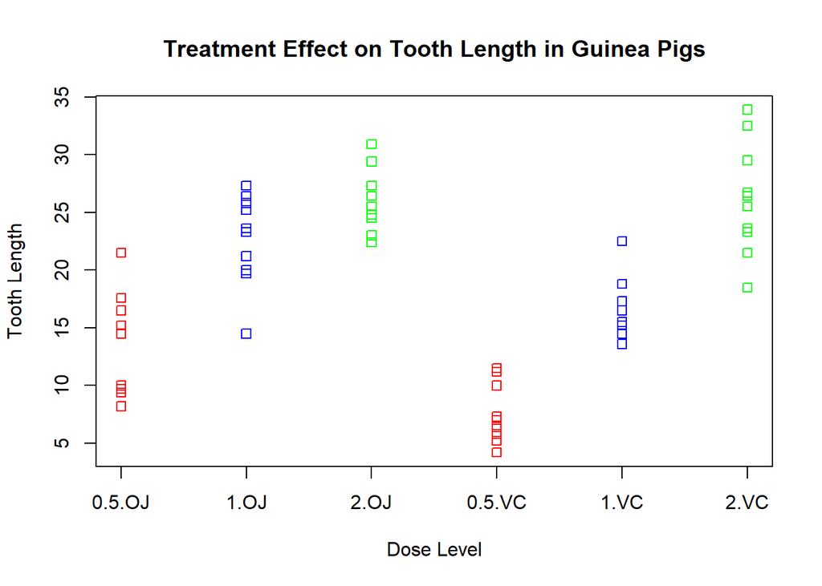

```r
stripchart(len ~ fdose * fsupp, data = toothgrowth, vertical = TRUE,
           col = c("red", "blue", "green"),
           main = "Treatment Effect on Tooth Length in Guinea Pigs",
           xlab = "Dose Level",
           ylab = "Tooth Length")
```

### Boxplot

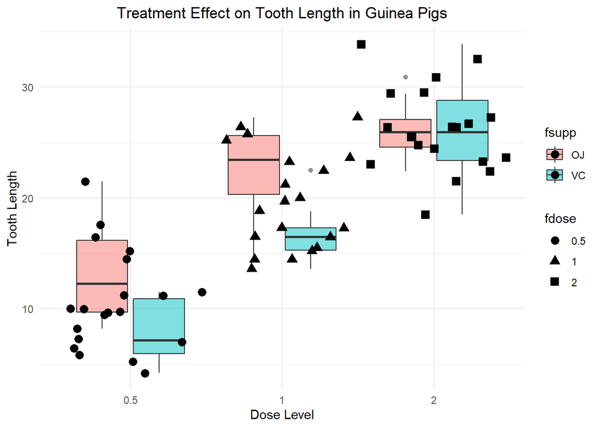

```r
#Boxplot
eda_plot <- ggplot(toothgrowth, aes(x = fdose, y = len, fill = fsupp)) +
  geom_boxplot(alpha = 0.5) +
  geom_jitter(aes(shape = fdose), width = 0.5, size = 3) +
  labs(
    title = "Treatment Effect on Tooth Length in Guinea Pigs",
    x = "Dose Level",
    y = "Tooth Length") +
  theme_minimal()+
  theme(
    plot.title = element_text(hjust = 0.5))

eda_plot
```

```r
#Save high-resolution PNG directly to figures folder
ggsave(
  filename = "../figures/boxplot_len_dose.png",
  plot = eda_plot,
  width = 10,
  height = 4.5,
  dpi = 200
)
```

### Group Means

```r
ms_tooth <- aggregate(len ~ fsupp * fdose, data = toothgrowth, FUN = mean)
```

Plot group means.

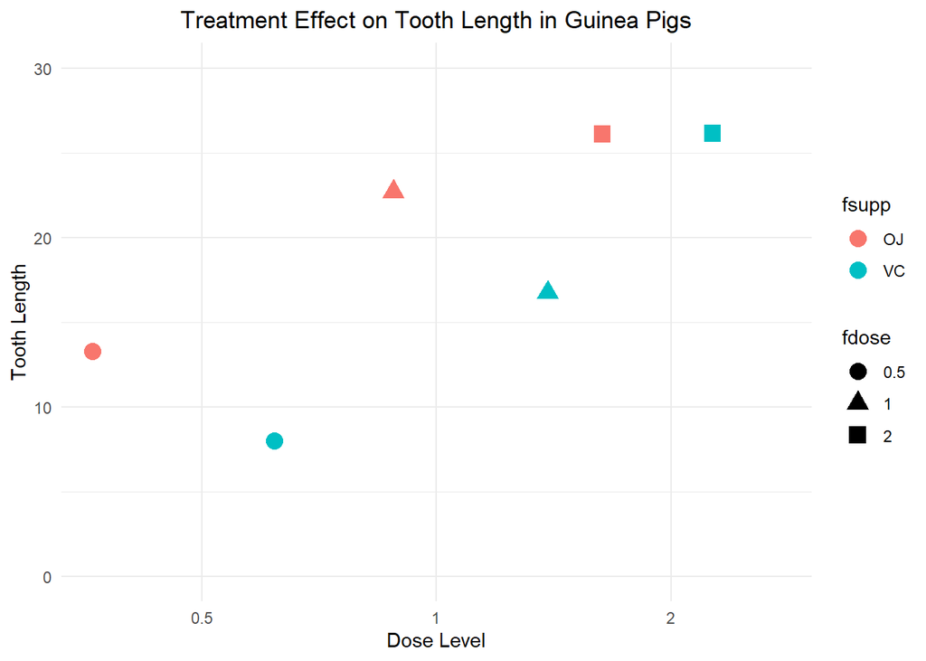

```r
ggplot(ms_tooth, aes(x = fdose, y = len, col = fsupp)) +
  geom_jitter(aes(shape = fdose), width = 0.5, size = 4) +
  scale_y_continuous(limits = c(0,30)) +
  labs(
    title = "Treatment Effect on Tooth Length in Guinea Pigs",
    x = "Dose Level",
    y = "Tooth Length") +
  theme_minimal()+
  theme(
    plot.title = element_text(hjust = 0.5))
```

Discussion: Exploratory analysis indicates the level of dosage with each supplement increases tooth length with orange juice on average producing a higher length of tooth growth with the exception of the 2mg dosage, vitamin C is slightly higher.

### Interactions Plot

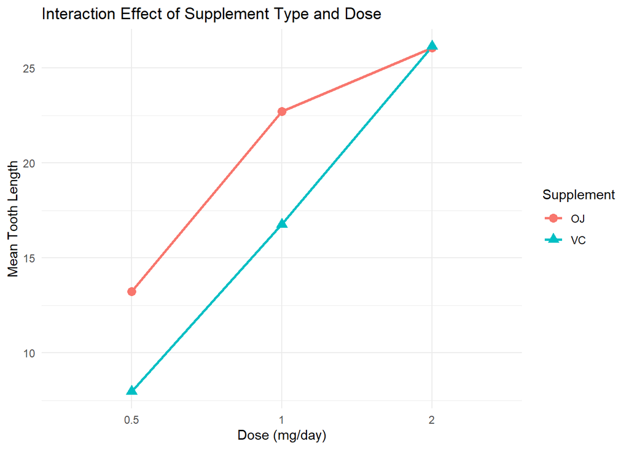

```r
#Interaction Plot
interaction_p <- ggplot(toothgrowth, aes(x = factor(dose), y = len, color = supp, group = supp)) +
  stat_summary(fun = mean, geom = "line", linewidth = 1) +
  stat_summary(fun = mean, geom = "point", size = 3, aes(shape = supp)) +
  labs(
    title = "Interaction Effect of Supplement Type and Dose",
    x = "Dose (mg/day)",
    y = "Mean Tooth Length",
    color = "Supplement",
    shape = "Supplement"
  ) +
  theme_minimal()
interaction_p
```

```r
#Save high-resolution PNG directly to figures folder
ggsave("../figures/interaction_plot.png", plot = interaction_p, width = 7, height = 5, dpi = 200)
```

# Statistical Modeling & Selection

### Hypothesis

- $H_0: \alpha \beta_{11} = \alpha\beta_{12} = ... = \alpha\beta_{ab} = 0$. There is no interaction effect between dose and supplements.
- $H_A:$ some $\alpha\beta's$ are not zero. There are interaction effects between dose and supplement.

### Model Fitting & Comparison

```r
p0 <- aov(len ~ fsupp, data = toothgrowth)
p1 <- aov(len ~ fsupp * dose, data = toothgrowth)
p2 <- aov(len ~ fsupp * (dose + I(dose^2)) ,data = toothgrowth)

aov_tooth <- aov(len ~ fsupp * fdose,
             data = toothgrowth)
anova_tooth <- anova(aov_tooth)


p0_tab <- anova(p0)
p1_tab <- anova(p1)
p2_tab <- anova(p2)
```

### Selection Criteria

**AIC Comparisons**

```r
#Create aic dataframe
aic_tooth <- AIC(p0, p1, p2)

options(knitr.kable.NA = ' ')

#Create table
kable(
    aic_tooth,
    caption = "AIC Comparison",
    align = c("l", "c", "c", "c"),
    format = "html"
  ) |>
    kable_styling(
      bootstrap_options = c("striped", "hover", "condensed"),
      full_width = FALSE,
      position = "center"
    )
```

AIC Comparison

|  | df | AIC |
| --- | --- | --- |
| p0 | 3 | 415.7386 |
| p1 | 5 | 344.9571 |
| p2 | 7 | 332.7056 |

**ANOVA Table: Model Terms Comparison**

```r
options(knitr.kable.NA = ' ')

#Create table
kable(
    p2_tab,
    caption = "Model Terms Comparison",
    align = c("l", "c", "c", "c"),
    format = "html"
  ) |>
    kable_styling(
      bootstrap_options = c("striped", "hover", "condensed"),
      full_width = FALSE,
      position = "center"
    )
```

Model Terms Comparison

|  | Df | Sum Sq | Mean Sq | F value | Pr(>F) |
| --- | --- | --- | --- | --- | --- |
| fsupp | 1 | 205.35000 | 205.35000 | 15.571979 | 0.0002312 |
| dose | 1 | 2224.30430 | 2224.30430 | 168.672125 | 0.0000000 |
| I(dose^2) | 1 | 202.13004 | 202.13004 | 15.327805 | 0.0002556 |
| fsupp:dose | 1 | 88.92011 | 88.92011 | 6.742937 | 0.0121009 |
| fsupp:I(dose^2) | 1 | 19.39889 | 19.39889 | 1.471045 | 0.2304601 |
| Residuals | 54 | 712.10600 | 13.18715 |  |  |

Discussion: In Table 1 it can be shown the polynomial interactions model (p2) yielded the lowest AIC value, supporting model with interactions and a quadratic term. However, two–way ANOVA results of the models indicate the interaction term supplement and the quadratic term dosage has no significant effect on the model (see Table 2). Based on the hierarchical principal of the two–way ANOVA test, its addition to the final model will be removed.

**Final Model**

The estimated final model includes the main effects dosage and supplement, the interaction between dosage and supplement, and the quadratic dosage term.

```r
#Interaction model
#Fit the model
final_tooth <- aov(len ~ fsupp + dose + I(dose^2)
               + fsupp:dose, data = toothgrowth)
```

**Final Model ANOVA Table**

```r
final_anova <- anova(final_tooth)

options(knitr.kable.NA = ' ')

#Create table
kable(
    final_anova,
    caption = "Final Model Terms Comparison",
    align = c("l", "c", "c", "c"),
    format = "html"
  ) |>
    kable_styling(
      bootstrap_options = c("striped", "hover", "condensed"),
      full_width = FALSE,
      position = "center"
    )
```

Final Model Terms Comparison

|  | Df | Sum Sq | Mean Sq | F value | Pr(>F) |
| --- | --- | --- | --- | --- | --- |
| fsupp | 1 | 205.35000 | 205.35000 | 15.439746 | 0.0002401 |
| dose | 1 | 2224.30430 | 2224.30430 | 167.239806 | 0.0000000 |
| I(dose^2) | 1 | 202.13004 | 202.13004 | 15.197645 | 0.0002654 |
| fsupp:dose | 1 | 88.92011 | 88.92011 | 6.685678 | 0.0123985 |
| Residuals | 55 | 731.50489 | 13.30009 |  |  |

# Model Diagnostics & Assumption Testing

A residuals versus fitted values plot. And a normal Q - Q plot with Shapiro - Wilk test.

```
##
##  Shapiro-Wilk normality test
##
## data:  resid(final_tooth)
## W = 0.9828, p-value = 0.5576
```

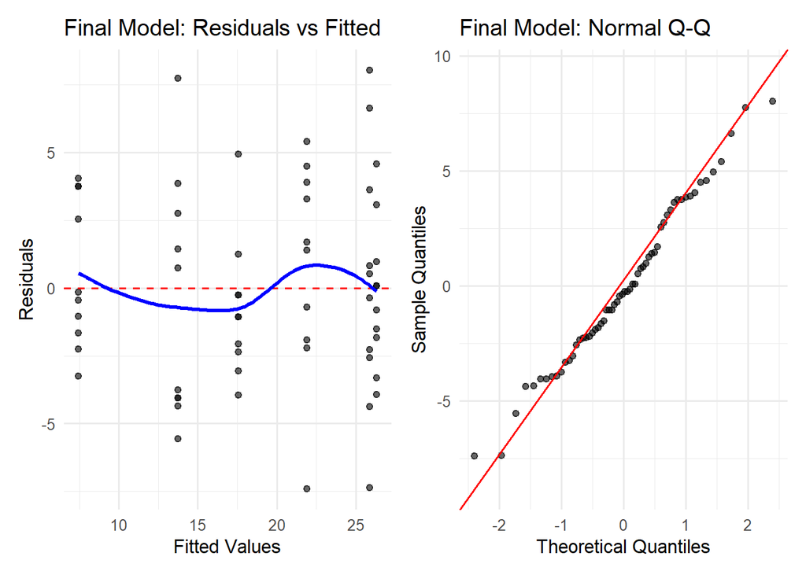

```r
#Augment the model to get a tidy data frame with residuals (.resid) & fitted values (.fitted)
aug_tooth <- augment(final_tooth)

#Residuals vs Fitted Plot
p_res <- ggplot(aug_tooth, aes(x = .fitted, y = .resid)) +
  geom_point(alpha = 0.6) +
  geom_hline(yintercept = 0, linetype = "dashed", color = "red") +
  geom_smooth(se = FALSE, color = "blue", method = "loess", formula = y ~ x) +
  labs(
    title = "Final Model: Residuals vs Fitted",
    x = "Fitted Values",
    y = "Residuals"
  ) +
  theme_minimal(base_size = 12)

#Normal Q-Q Plot
p_qq <- ggplot(aug_tooth, aes(sample = .resid)) +
  stat_qq(alpha = 0.6) +
  stat_qq_line(color = "red") +
  labs(
    title = "Final Model: Normal Q-Q",
    x = "Theoretical Quantiles",
    y = "Sample Quantiles"
  ) +
  theme_minimal(base_size = 12)

#Combine side-by-side & save cleanly with ggsave()
final_diag <- p_res + p_qq
final_diag
ggsave(
  filename = "../figures/final_diagnostics.png",
  plot = final_diag,
  width = 10,
  height = 4.5,
  dpi = 200
)

#Shapiro - Wilk Test
shap1 <- shapiro.test(resid(final_tooth))
shap1
```

Discussion: The normal Q–Q plot indicates the residuals approximately follow a normal distribution.There is slight deviation from the line and at the tails. To confirm normality the Shapiro–Wilk test is conducted and has resulted in a high W = 0.9828 and p–value of 0.5576, satisfying the normality assumption. The residuals versus fitted values indicates equal variance and thus is satisfied, no clear patterns are observed.

# Post-Hoc Analysis & conclusion

### Estimated Marginal Means

```r
em_tooth <- emmeans(aov_tooth, pairwise ~ fsupp | fdose)
```

### Pairwise Contrast Comparisons

```r
em_tb <- em_tooth$contrasts

options(knitr.kable.NA = ' ')

#Create table
kable(
    em_tb,
    caption = "Pairwise Comparisons",
    digits = 4,
    align = c("l", "c", "c", "c"),
    format = "html"
  ) |>
    kable_styling(
      bootstrap_options = c("striped", "hover", "condensed"),
      full_width = FALSE,
      position = "center"
    )
```

Pairwise Comparisons

| contrast | fdose | estimate | SE | df | t.ratio | p.value |
| --- | --- | --- | --- | --- | --- | --- |
| OJ - VC | 0.5 | 5.25 | 1.624 | 54 | 3.2327 | 0.0021 |
| OJ - VC | 1 | 5.93 | 1.624 | 54 | 3.6514 | 0.0006 |
| OJ - VC | 2 | -0.08 | 1.624 | 54 | -0.0493 | 0.9609 |

### Contrast Visualizations

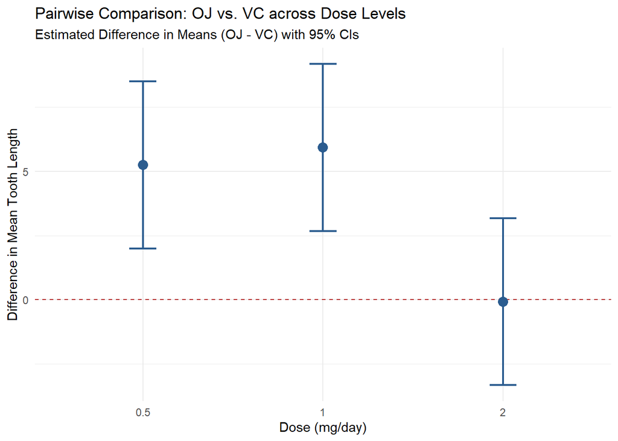

```r
#Convert emmeans output to a data frame for ggplot
contrast_df <- as.data.frame(em_tooth$contrasts)

#Add 95% Confidence Intervals manually using SE and critical t-value
contrast_df$lower_CI <- contrast_df$estimate - (qt(0.975, df = contrast_df$df) * contrast_df$SE)
contrast_df$upper_CI <- contrast_df$estimate + (qt(0.975, df = contrast_df$df) * contrast_df$SE)

#Plot nested contrasts
contrast_p <- ggplot(contrast_df, aes(x = fdose, y = estimate)) +
  geom_hline(yintercept = 0, linetype = "dashed", color = "firebrick") +
  geom_point(size = 3.5, color = "#2b5c8f") +
  geom_errorbar(aes(ymin = lower_CI, ymax = upper_CI), width = 0.15, linewidth = 0.8, color = "#2b5c8f") +
  labs(
    title = "Pairwise Comparison: OJ vs. VC across Dose Levels",
    subtitle = "Estimated Difference in Means (OJ - VC) with 95% CIs",
    x = "Dose (mg/day)",
    y = "Difference in Mean Tooth Length"
  ) +
  theme_minimal()
contrast_p
```

```r
#Save image
ggsave("../figures/nested_contrasts_plot.png", plot = contrast_p, width = 7, height = 5, dpi = 300)
```